# homework3

Collin

4/28/2021

# Question 8

*a)* *Use the rnorm() function to generate a predictorXof lengthn= 100, as well as a noise vector"of lengthn=100.*

```r
predictorX = rnorm(100, 0,10)
noise = rnorm(100, 0, 20)
```

*b)* *generate a response vectorY of length n= 100 according to the model*
$$Y = \beta_{0} + \beta_{1}X_{1} + \beta_{2}X_{2}^2 + \beta_{3}X_{3}^3$$

```r
beta0 = 3
beta1 = 2
beta2 = -.5
beta3 = .05

Y = beta0 + beta1*predictorX + beta2*predictorX + beta3*predictorX + noise

df = data.frame(Y = Y, X= predictorX)
```

*c)* *Use theregsubsets()function to perform best subset selection in order to choose the best model containing the predictorsX,X2,…,X10. What is the best model obtained according to Cp,BIC,andadjustedR2?Showsomeplotstoprovideevidencefor your answer, and report the coefficients of the best model ob-tained. Note you will need to use the data.frame()function tocreate a single data set containing bothXandY.*

```r
fit = regsubsets(Y ~ poly(X, 10), data = df, nvmax = 10)

fit_summary = summary(fit)
fit_summary$cp
```

```
##  [1] -0.1106208 -2.4786935 -1.8399104 -0.5932935  1.3001052  3.2189562
##  [7]  5.1386959  7.0699330  9.0077501 11.0000000
```

```r
fit_summary$adjr2
```

```
##  [1] 0.3984771 0.4199596 0.4226344 0.4214322 0.4159744 0.4102310 0.4043568
##  [8] 0.3982758 0.3920147 0.3852369
```

```r
fit_summary$bic
```

```
##  [1] -42.63396 -42.69113 -39.58445 -35.81840 -31.33253 -26.81827 -22.30310
##  [8] -17.77510 -13.23977  -8.64331
```

```r
which.min(fit_summary$cp)
```

```
## [1] 2
```

```r
coef(fit, id = 4)
```

```
##  (Intercept) poly(X, 10)1 poly(X, 10)2 poly(X, 10)4 poly(X, 10)6
##   -0.0793969  159.9258106   41.4106494   23.1169636  -17.1978853
```

```r
#found these plots online and thought they looked pretty cool so I included them
# tibble(Cp = fit_summary$cp,
#            BIC = fit_summary$bic,
#            AdjR2 = fit_summary$adjr2) %>%
#     mutate(id = row_number()) %>%
#     gather(value_type, value, -id) %>%
#     ggplot(aes(id, value, col = value_type)) +
#     geom_line() + geom_point() + ylab('') + xlab('Number of Variables Used') +
#     facet_wrap(~ value_type, scales = 'free') +
#     theme_minimal() + scale_x_continuous(breaks = 1:10)
```

*d)* *Repeat (c), using forward stepwise selection and also using back-wards stepwise selection. How does your answer compare to theresults in (c)?*

```r
#forward
forward_model = regsubsets(Y ~ poly(X, 10), data = df,
                           method = "forward")
forward_summary = summary(forward_model)
which.min(forward_summary$cp)
```

```
## [1] 2
```

```r
which.min(forward_summary$bic)
```

```
## [1] 2
```

```r
which.max(forward_summary$adjr2)
```

```
## [1] 3
```

```r
coef(forward_model, id = 4)
```

```
##  (Intercept) poly(X, 10)1 poly(X, 10)2 poly(X, 10)4 poly(X, 10)6
##   -0.0793969  159.9258106   41.4106494   23.1169636  -17.1978853
```

```r
#best backward
backward_model = regsubsets(Y ~ poly(X, 10), data = df,
                           method = "backward")
backward_summary = summary(backward_model)
which.min(backward_summary$cp)
```

```
## [1] 2
```

```r
which.min(backward_summary$bic)
```

```
## [1] 2
```

```r
which.max(backward_summary$adjr2)
```

```
## [1] 3
```

```r
coef(forward_model, id = 4)
```

```
##  (Intercept) poly(X, 10)1 poly(X, 10)2 poly(X, 10)4 poly(X, 10)6
##   -0.0793969  159.9258106   41.4106494   23.1169636  -17.1978853
```

*e)* *Now fit a lasso model to the simulated data, again usingX,X2,…,X10as predictors. Use cross-validation to select the optimalvalue ofλ. Create plots of the cross-validation error as a functionofλ.Report theresultingcoefficient estimates, and discuss theresults obtained.*

```r
library(gamlr)
#estimate LASSO
model_matrix = model.matrix(Y ~ poly(X,10), data = df)

lasso = cv.gamlr(model_matrix, Y)
summary(lasso)
```

```
##
## 5-fold gaussian cv.gamlr object
```

```
##            lambda par     oos.r2
## seg1   15.9925811   1 0.00000000
## seg2   15.2656936   2 0.01840317
## seg3   14.5718442   2 0.04450045
## seg4   13.9095314   2 0.07537498
## seg5   13.2773218   2 0.10351134
## seg6   12.6738470   2 0.12915257
## seg7   12.0978011   2 0.15252012
## seg8   11.5479374   2 0.17381580
## seg9   11.0230658   2 0.19322347
## seg10  10.5220504   2 0.21091069
## seg11  10.0438070   2 0.22703013
## seg12   9.5873005   2 0.24172091
## seg13   9.1515429   2 0.25510980
## seg14   8.7355911   2 0.26731230
## seg15   8.3385450   2 0.27843368
## seg16   7.9595453   2 0.28856984
## seg17   7.5977717   2 0.29780818
## seg18   7.2524412   2 0.30622835
## seg19   6.9228066   2 0.31390291
## seg20   6.6081543   2 0.32089799
## seg21   6.3078035   2 0.32727385
## seg22   6.0211041   2 0.33308539
## seg23   5.7474356   2 0.33838266
## seg24   5.4862058   2 0.34321125
## seg25   5.2368493   2 0.34761271
## seg26   4.9988264   2 0.35165184
## seg27   4.7716220   2 0.35537118
## seg28   4.5547444   2 0.35886336
## seg29   4.3477243   2 0.36211731
## seg30   4.1501135   2 0.36521792
## seg31   3.9614844   3 0.36827064
## seg32   3.7814289   3 0.37105088
## seg33   3.6095571   3 0.37358292
## seg34   3.4454971   3 0.37588885
## seg35   3.2888940   3 0.37798881
## seg36   3.1394087   3 0.37990117
## seg37   2.9967177   3 0.38164262
## seg38   2.8605123   3 0.38312884
## seg39   2.7304976   3 0.38367081
```

[output cut: 46 more lines]

```
## seg86   0.3067234  10 0.31313553
## seg87   0.2927823  10 0.31191331
## seg88   0.2794749  10 0.31067669
## seg89   0.2667723  10 0.30946331
## seg90   0.2546471  10 0.30828182
## seg91   0.2430730  10 0.30713472
## seg92   0.2320250  10 0.30602286
## seg93   0.2214791  10 0.30494671
## seg94   0.2114125  10 0.30394017
## seg95   0.2018035  10 0.30295205
## seg96   0.1926312  10 0.30199057
## seg97   0.1838758  10 0.30104622
## seg98   0.1755184  10 0.30012505
## seg99   0.1675408  11 0.29923592
## seg100  0.1599258  11 0.29837860
```

```r
#SElection criteria:
#CV-Min: chooses smalleset out of sample SSE
lambda_min = lasso$seg.min
lasso$gamlr$lambda[lambda_min] #lambda that minimizes SSE
```

```
##    seg39
## 2.730498
```

```r
#1standard error away rule
lambda_1se = lasso$seg.1se
lasso$gamlr$lambda[lambda_1se]
```

```
##    seg21
## 6.307804
```

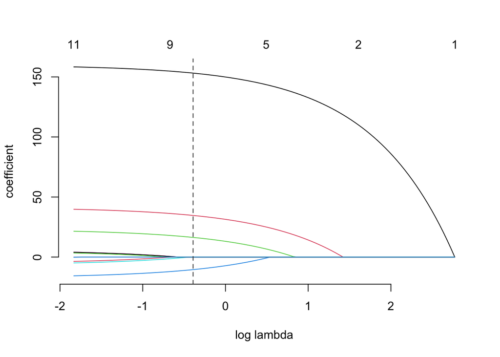

```r
#Aic

#Bic

#Path plot
plot(lasso$gamlr)
```

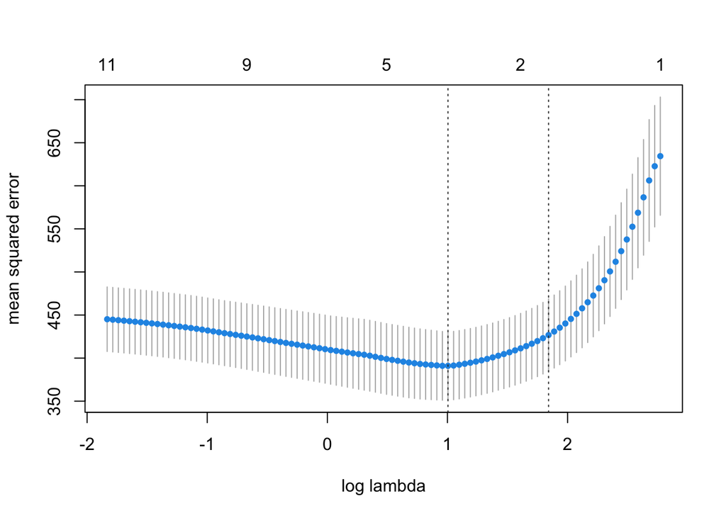

```r
plot(lasso)
```

```r
coef(lasso, select = "min")
```

```
## 12 x 1 sparse Matrix of class "dgCMatrix"
##                     seg39
## intercept      -0.0793969
## (Intercept)     .
## poly(X, 10)1  132.6208350
## poly(X, 10)2   14.1056738
## poly(X, 10)3    .
## poly(X, 10)4    .
## poly(X, 10)5    .
## poly(X, 10)6    .
## poly(X, 10)7    .
## poly(X, 10)8    .
## poly(X, 10)9    .
## poly(X, 10)10   .
```

*f)* *now generate a response vectorY according to the model*

```r
newY <- 3 + 8*predictorX^7 + noise

new_df = data_frame(Y = newY, X = predictorX)
```

```r
fit <- regsubsets(Y ~ poly(X, 10), data = new_df, nvmax = 10)

fit_summary <- summary(fit)


# tibble(Cp = fit_summary$cp,
#            BIC = fit_summary$bic,
#            R2 = fit_summary$adjr2) %>%
#     mutate(id = row_number()) %>%
#     gather(value_type, value, -id) %>%
#     ggplot(aes(id, value, col = value_type)) +
#     geom_line() + geom_point() + ylab('') + xlab('Number of Variables Used') +
#     facet_wrap(~ value_type, scales = 'free') +
#     theme_minimal() + scale_x_continuous(breaks = 1:10)
```

#2

## a)

```r
library(ISLR)
data = College
dim(data)
```

```
## [1] 777  18
```

```r
n = nrow(data)
K = 5
foldid = rep(1:K, each = ceiling(n/K))[sample(1:n)]
?rep
```

[output not shown]

```r
train = data[which(foldid != 1),]
test = data[-which(foldid !=1),]
```

##b)

```r
ols = lm(Apps ~ ., data = train)
#predict
ols_predictions = predict(ols, test)

#calcualte out of sample SSE
ols_oos = mean( (test$Apps - ols_predictions )^2 )


#use the postResmaple function and see if you can get it
postResample(test$Apps,ols_predictions)
```

```
##         RMSE     Rsquared          MAE
## 1226.9342133    0.8892907  675.3819507
```

##c)

```r
y = train$Apps

grid = 10^seq(4,-2,length = 100)

ridge = cv.glmnet(X,y, lambda = grid)

#obtain predictions and find out of sample deviance
xtest = model.matrix(Apps ~ ., data = test)
ridge_pred = predict(ridge, newx = xtest, select = ridge$lambda.min)

#calculate oos
ridge_oos = mean( (test$Apps - ridge_pred)^2)
ridge_oos
```

```
## [1] 2030756
```

##d)

```r
library(gamlr)
library(tidyverse)
#estimate the LASSO model on the training data
X - model.matrix(Apps ~ ., data = train)
```

[output not shown]

[output cut: 3682 more lines]

[output not shown]

```r
y = train$Apps

lasso = cv.gamlr(X,y, nlambda = 1000, lambda.start = Inf, lambda.min.ratio = .001)

#obtain predictions
xtest = model.matrix(Apps ~ ., data = test)
lasso_pred = predict(lasso, newdata = xtest, select = "min")

lasso_oos = mean( (test$Apps - lasso_pred)^2)


RSS = c(ols_oos,ridge_oos,lasso_oos)
Model = c("OLS", "Ridge", "Lasso")
out = rbind(Model, round(RSS,2))
out
```

```
##       [,1]         [,2]        [,3]
## Model "OLS"        "Ridge"     "Lasso"
##       "1505367.56" "2030756.3" "1552064.83"
```

#3 #a)

```r
set.seed(10101)
#set p = 20, n = 1000
p = 20
n = 1000

X = matrix(rnorm(n*p),n,p)
#generate beta and outcome

B = rnorm(p)
B[3] = 0
B[9] = 0
B[4] = 0

e = rnorm(n)
y = X %*%B + e

#df
data = data.frame(y,X)
```

```r
#training data index
test_sample = sample(seq(1000),100, replace = FALSE)
test = data[test_sample,]
train = data[-test_sample,]
```

#c)

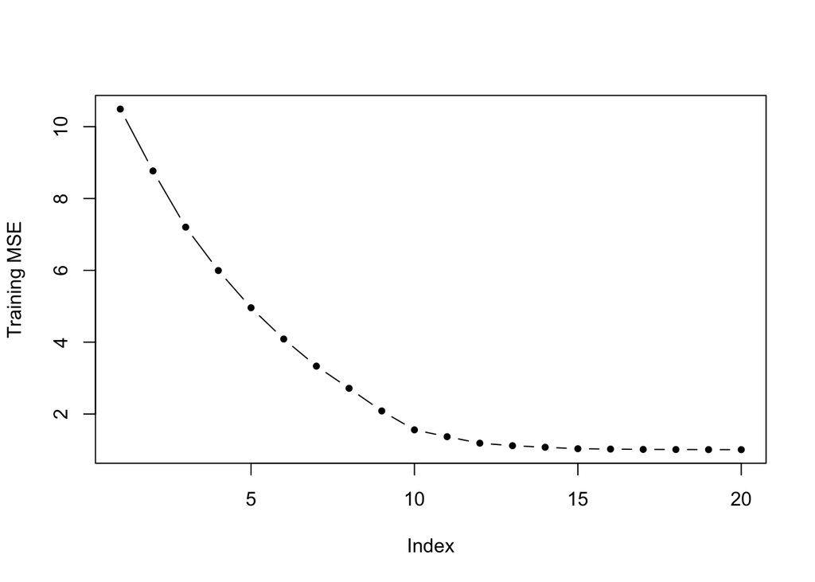

```r
bestsubset = regsubsets(y~.,data = train, nvmax = 20)

#graph
matrix = model.matrix(y ~ .,data = train)

bestsubset_is = rep(NA,p)
for(i in 1:20){
    coefi = coef(bestsubset,id = i)
    pred = matrix[,names(coefi)]%*%coefi
    bestsubset_is[i] = mean((train$y - pred)^2)
}
plot(bestsubset_is, ylab = "Training MSE", pch = 20, type = "b")
```

The important thing to note here that the training MSE *always* decreases with the addition of new predictors.

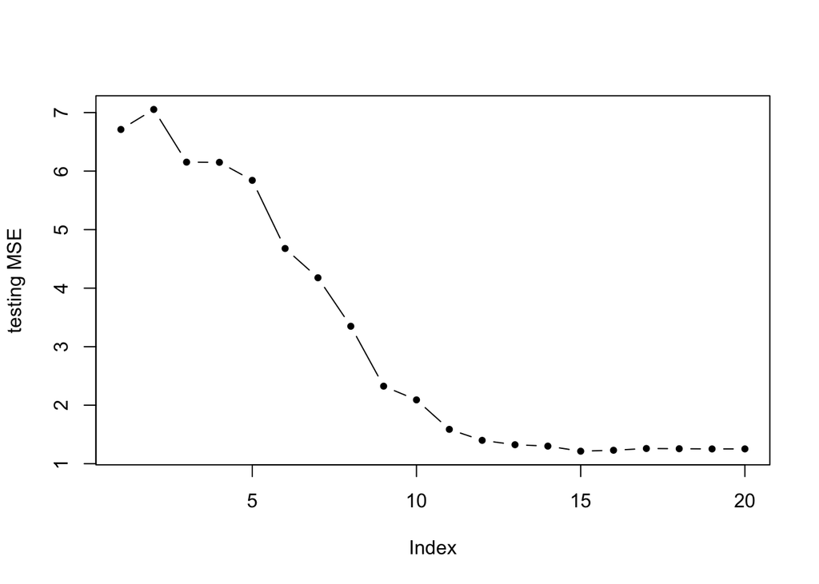

```r
matrix = model.matrix(y ~ .,data = test)

bestsubset_oos = rep(NA,p)
for(i in 1:20){
    coefi = coef(bestsubset,id = i)
    pred = matrix[,names(coefi)]%*%coefi
    bestsubset_oos[i] = mean((test$y - pred)^2)
}
plot(bestsubset_oos, ylab = "testing MSE", pch = 20, type = "b")
```

Now note that each additional predictor does not always result in a reduction of *testing* MSE. This is an incredibly important distinction.

#e)

```r
#in sample MSE
which.min(bestsubset_is)
```

```
## [1] 20
```

```r
#OOS
which.min(bestsubset_oos)
```

```
## [1] 15
```

The model takes on its lowest MSE value with 15 predictors (compared to the training model’s lowest MSE value which unsurprisingly comes with the maximum number of predictors we tried).